# Hayward, George - IAS Code - May 11, 2024_ anon

**Executive Summary**

Executives should focus on **customer retention** because customers seem to be price sensitive. Bringing highly engaged customers down from the **\$90** to the **\$70** monthly charge price point may increase retention. This can be achieved through a promotion, which we will A/B test. Increased customer lifetime value and decreased customer acquisition cost can offset the price of this promotion.

[figure not shown]

**Table of Contents**

**Part 1: Data Exploration and Filtering**

- Question 1.1
- Question 1.2
- Question 1.3

**Part 2. Segmentation and Analysis**

- Question 2.1
- Question 2.2
- Question 2.3
- Question 2.4

**Part 3. Predictive Modeling (Bonus)**

- Question 3.1
- Question 3.2

**Part 4. Recommendations**

Thank you for your time and consideration.

**George Hayward, Esq.**  
george@haywarddatascience.com  
May 10, 2024  
New York, New York  
*"The Lord Always Delivers!"*

```python
import haywarddatascience as hds
from haywarddatascience import HaywardSQLAnalysis, HaywardDataScience, HaywardGeneral
```

Table of Contents

Part 1. Data Exploration and Filtering

*Question 1.1:* *Generate summary statistics for numerical features and provide interpretations.*

```python
ias_df = hds.pd.read_csv("ias_data/DATA_staff_data_analyst_take_home_test.csv")
```

```python
# check for uniqueness
ias_df.customerID.is_unique
```

```
True
```

```python
ias_df.head()
```

|  | customerID | gender | SeniorCitizen | Partner | Dependents | tenure | PhoneService | MultipleLines | InternetService | OnlineSecurity | OnlineBackup | DeviceProtection | TechSupport | StreamingTV | StreamingMovies | Contract | PaperlessBilling | PaymentMethod | MonthlyCharges | TotalCharges | Churn |
| --- | --- | --- | --- | --- | --- | --- | --- | --- | --- | --- | --- | --- | --- | --- | --- | --- | --- | --- | --- | --- | --- |
| 0 | 7590-VHVEG | Female | 0 | Yes | No | 1 | No | No phone service | DSL | No | Yes | No | No | No | No | Month-to-month | Yes | Electronic check | 29.85 | 29.85 | No |
| 1 | 5575-GNVDE | Male | 0 | No | No | 34 | Yes | No | DSL | Yes | No | Yes | No | No | No | One year | No | Mailed check | 56.95 | 1889.5 | No |
| 2 | 3668-QPYBK | Male | 0 | No | No | 2 | Yes | No | DSL | Yes | Yes | No | No | No | No | Month-to-month | Yes | Mailed check | 53.85 | 108.15 | Yes |
| 3 | 7795-CFOCW | Male | 0 | No | No | 45 | No | No phone service | DSL | Yes | No | Yes | Yes | No | No | One year | No | Bank transfer (automatic) | 42.30 | 1840.75 | No |
| 4 | 9237-HQITU | Female | 0 | No | No | 2 | Yes | No | Fiber optic | No | No | No | No | No | No | Month-to-month | Yes | Electronic check | 70.70 | 151.65 | Yes |

```python
# data types seem off
ias_df.describe()
```

|  | SeniorCitizen | tenure | MonthlyCharges |
| --- | --- | --- | --- |
| count | 7043.00 | 7043.00 | 7042.00 |
| mean | 0.16 | 32.65 | 64.76 |
| std | 0.37 | 33.95 | 30.09 |
| min | 0.00 | 0.00 | 18.25 |
| 25% | 0.00 | 9.00 | 35.50 |
| 50% | 0.00 | 29.00 | 70.35 |
| 75% | 0.00 | 55.00 | 89.85 |
| max | 3.00 | 2000.00 | 118.75 |

```python
# check types
ias_df.dtypes
```

```
customerID           object
gender               object
SeniorCitizen         int64
Partner              object
Dependents           object
tenure                int64
PhoneService         object
MultipleLines        object
InternetService      object
OnlineSecurity       object
OnlineBackup         object
DeviceProtection     object
TechSupport          object
StreamingTV          object
StreamingMovies      object
Contract             object
PaperlessBilling     object
PaymentMethod        object
MonthlyCharges      float64
TotalCharges         object
Churn                object
dtype: object
```

```python
# remove error
ias_df['SeniorCitizen'].value_counts()
```

```
0    5900
1    1142
3       1
Name: SeniorCitizen, dtype: int64
```

```python
# begin to clean this
ias_df_wrangled = ias_df[ias_df['SeniorCitizen'].isin([0, 1])]
```

```python
# change the objects to numbers, and send error to NULL
# safer to treat Senior boolean as object, b/c it's a categorical
ias_df_wrangled['TotalCharges'] = hds.pd.to_numeric(ias_df_wrangled['TotalCharges'], errors='coerce')
ias_df_wrangled['SeniorCitizen'] = ias_df_wrangled['SeniorCitizen'].astype('object')
```

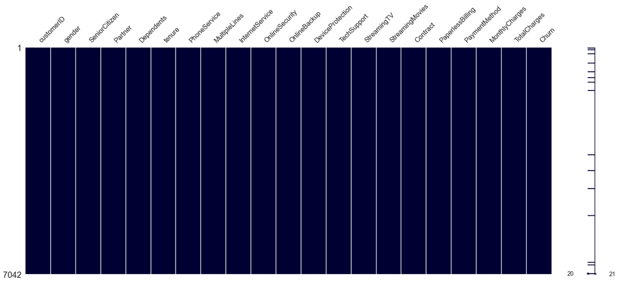

```python
#check nulls
hds.msno.matrix(ias_df_wrangled,  color = (.0,.0,.2))
```

```python
# some nulls, but for exam time purposes will keep going
# before deleting nulls, we would want to see if there is a pattern there, but for exam will just delete
```

```python
ias_df_wrangled = ias_df_wrangled.dropna()
```

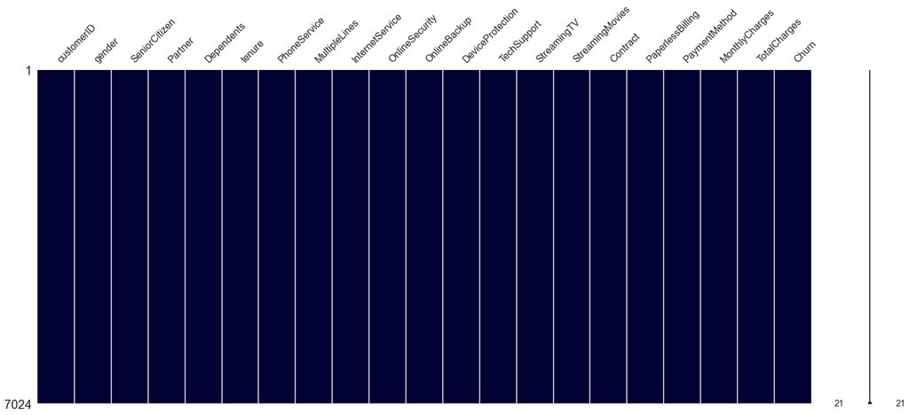

```python
hds.msno.matrix(ias_df_wrangled,  color = (.0,.0,.2))
```

```python
ias_df_wrangled.dtypes
```

```
customerID           object
gender               object
SeniorCitizen        object
Partner              object
Dependents           object
tenure                int64
PhoneService         object
MultipleLines        object
InternetService      object
OnlineSecurity       object
OnlineBackup         object
DeviceProtection     object
TechSupport          object
StreamingTV          object
StreamingMovies      object
Contract             object
PaperlessBilling     object
PaymentMethod        object
MonthlyCharges      float64
TotalCharges        float64
Churn                object
dtype: object
```

```python
ias_df_wrangled.describe()
```

|  | tenure | MonthlyCharges | TotalCharges |
| --- | --- | --- | --- |
| count | 7024.00 | 7024.00 | 7024.00 |
| mean | 32.71 | 64.80 | 53197.09 |
| std | 33.96 | 30.08 | 4267028.73 |
| min | 1.00 | 18.25 | 18.80 |
| 25% | 9.00 | 35.64 | 401.45 |
| 50% | 29.00 | 70.35 | 1397.47 |
| 75% | 55.00 | 89.86 | 3796.91 |
| max | 2000.00 | 118.75 | 357618955.40 |

```python
#clearly we have some outliers here
```

```
Percentile 1: 1.0
Percentile 25: 9.0
Percentile 50: 29.0
Percentile 75: 55.0
Percentile 90: 69.0
Percentile 95: 72.0
Percentile 97.0: 72.0
Percentile 98.0: 72.0
Percentile 99.0: 72.0
Percentile 99.7: 72.0
Percentile 99.9: 72.0
Percentile 99.99: 645.97
```

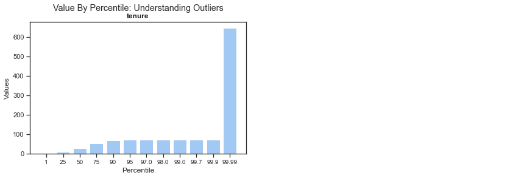

```python
HaywardGeneral.hayward_percentiler_Python(ias_df_wrangled, "tenure")
```

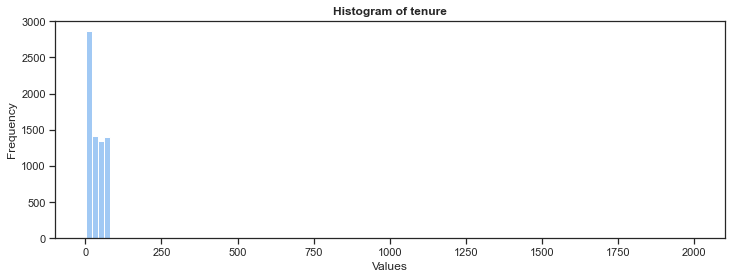

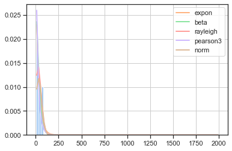

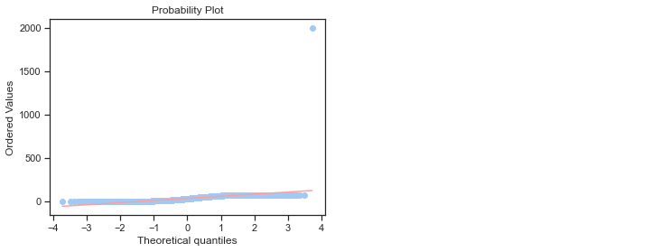

```python
HaywardGeneral.hayward_distribution_visualizer_and_fitter(ias_df_wrangled, "tenure")
```

```
Percentile 1: 19.2
Percentile 25: 35.64
Percentile 50: 70.35
Percentile 75: 89.86
Percentile 90: 102.65
Percentile 95: 107.44
Percentile 97.0: 110.1
Percentile 98.0: 111.58
Percentile 99.0: 114.74
Percentile 99.7: 116.45
Percentile 99.9: 117.6
Percentile 99.99: 118.68
```

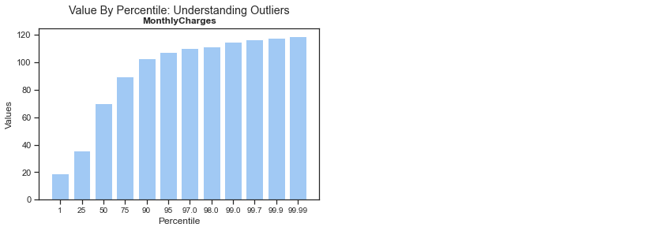

```python
HaywardGeneral.hayward_percentiler_Python(ias_df_wrangled, "MonthlyCharges")
```

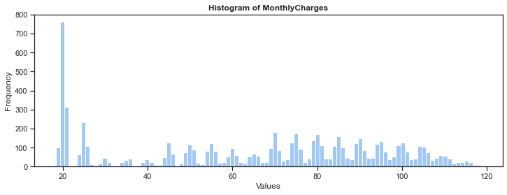

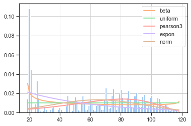

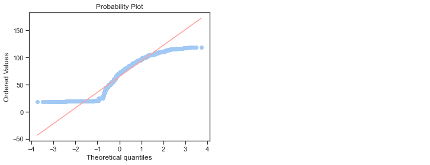

```python
HaywardGeneral.hayward_distribution_visualizer_and_fitter(ias_df_wrangled, "MonthlyCharges")
```

```
Percentile 1: 19.9
Percentile 25: 401.45
Percentile 50: 1397.48
Percentile 75: 3796.91
Percentile 90: 5978.86
Percentile 95: 6928.87
Percentile 97.0: 7424.78
Percentile 98.0: 7723.81
Percentile 99.0: 8045.65
Percentile 99.7: 8404.5
Percentile 99.9: 8542.93
Percentile 99.99: 106469262.36
```

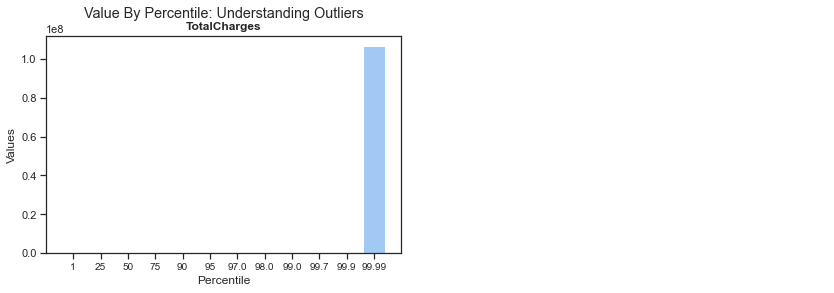

```python
HaywardGeneral.hayward_percentiler_Python(ias_df_wrangled, "TotalCharges")
```

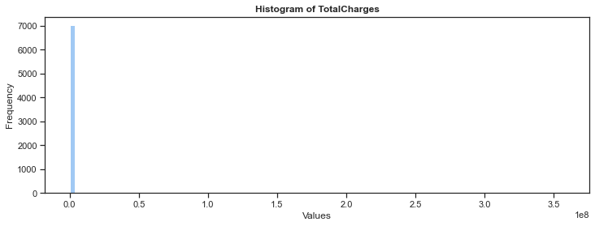

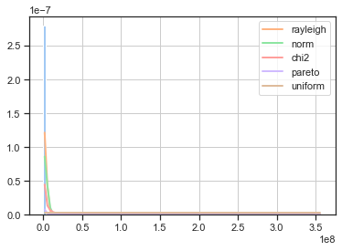

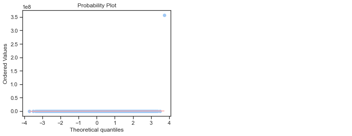

```python
HaywardGeneral.hayward_distribution_visualizer_and_fitter(ias_df_wrangled, "TotalCharges")
```

**1.1 Quick Summary:**

This data has extreme outliers, which is very common in tech. We can't just eliminate these outliers because they could be whale-customers, who should have their own metrics and their own strategy.

See above for percentiles. We will almost always speak in terms of percentiles so that we get a better idea of the data, not influenced by super-customers (outliers).

Note that, in the interest of time, I've simply dropped the NULLs, and cut out the false boolean 3 in the `SeniorCitizen` column. Usually, though, NULLs would get their own analysis just to make sure they are not systematically patterned.

Typically for product analysis, though not here due to exam time constraints, I'll focus on the Inter-Quartile Range to actually look at the relationship among and between features.

Table of Contents

*Question 1.2:* *Identify the proportion of churned customers versus retained customers.*

```python
ias_q_1_2 = HaywardSQLAnalysis("ias")
```

```python
ias_q_1_2.sendToSQL(ias_df_wrangled, "ias")
```

```python
question1_part2 = ias_q_1_2.inlineSQL("""
SELECT
    churn as churn_status,
    count(distinct customerID) as customers,
    (1.0*count(distinct customerID)) / sum(count(distinct customerID)) over() as percentage
FROM ias
GROUP BY 1
""")
```

```python
question1_part2
```

|  | churn_status | customers | percentage |
| --- | --- | --- | --- |
| 0 | No | 5156 | 0.73 |
| 1 | Yes | 1868 | 0.27 |

**1.2 Quick Summary:**

**73%** not churned.

**27%** churned.

Table of Contents

*Question 1.3:* *Filter the dataset to include only customers with a tenure greater than 1 year and TotalCharges more than 70th percentile.*

```python
ias_q_1_3 = HaywardSQLAnalysis("ias")
ias_q_1_3.sendToSQL(ias_df_wrangled, "ias")
```

```python
total_charges_p70 = ias_df_wrangled['TotalCharges'].quantile(0.70)
```

```python
question1_part3 = ias_q_1_3.inlineSQL(f"""
SELECT
    *
FROM ias
WHERE 1=1
AND tenure > 1
AND totalcharges > {total_charges_p70}
""")
```

```python
question1_part3.sample(10)
```

|  | customerID | gender | SeniorCitizen | Partner | Dependents | tenure | PhoneService | MultipleLines | InternetService | OnlineSecurity | OnlineBackup | DeviceProtection | TechSupport | StreamingTV | StreamingMovies | Contract | PaperlessBilling | PaymentMethod | MonthlyCharges | TotalCharges | Churn |
| --- | --- | --- | --- | --- | --- | --- | --- | --- | --- | --- | --- | --- | --- | --- | --- | --- | --- | --- | --- | --- | --- |
| 1241 | 7572-KPVKK | Male | 0 | No | Yes | 62 | Yes | Yes | Fiber optic | No | No | Yes | Yes | Yes | Yes | Two year | Yes | Electronic check | 104.05 | 6590.50 | No |
| 1235 | 7030-FZTFM | Male | 0 | Yes | Yes | 72 | Yes | Yes | Fiber optic | No | Yes | Yes | Yes | Yes | Yes | Two year | No | Credit card (automatic) | 110.90 | 7922.75 | No |
| 17 | 8012-SOUDQ | Female | 1 | No | No | 43 | Yes | Yes | Fiber optic | No | Yes | No | No | Yes | No | Month-to-month | Yes | Electronic check | 90.25 | 3838.75 | No |
| 1199 | 6762-QVYJO | Female | 0 | Yes | Yes | 58 | No | No phone service | DSL | Yes | No | Yes | Yes | Yes | Yes | Two year | No | Mailed check | 59.75 | 3624.35 | No |
| 1142 | 0237-YFUTL | Female | 0 | Yes | No | 50 | Yes | Yes | Fiber optic | Yes | Yes | No | Yes | Yes | Yes | Month-to-month | Yes | Bank transfer (automatic) | 109.65 | 5405.80 | No |
| 1367 | 9470-YFUYI | Male | 1 | Yes | No | 71 | Yes | No | DSL | Yes | Yes | No | Yes | Yes | No | One year | Yes | Bank transfer (automatic) | 71.00 | 5012.10 | No |
| 1552 | 1527-SXDPN | Male | 0 | Yes | Yes | 52 | Yes | Yes | Fiber optic | No | No | Yes | Yes | No | Yes | Two year | Yes | Bank transfer (automatic) | 96.25 | 4990.25 | Yes |
| 1561 | 7399-QHBJS | Female | 0 | Yes | Yes | 72 | Yes | Yes | DSL | Yes | Yes | No | Yes | No | No | Two year | No | Credit card (automatic) | 66.75 | 4760.30 | No |
| 1463 | 2272-WUSPA | Female | 0 | Yes | No | 72 | Yes | Yes | Fiber optic | Yes | Yes | Yes | No | Yes | Yes | Two year | Yes | Electronic check | 110.75 | 7751.70 | No |
| 1412 | 2284-VFLKH | Male | 0 | Yes | No | 49 | Yes | No | Fiber optic | No | No | Yes | Yes | Yes | Yes | One year | Yes | Credit card (automatic) | 99.25 | 4920.80 | No |

```python
print(total_charges_p70)
```

```
3143.7999999999993
```

```python
question1_part3.describe()
```

|  | SeniorCitizen | tenure | MonthlyCharges | TotalCharges |
| --- | --- | --- | --- | --- |
| count | 2107.00 | 2107.00 | 2107.00 | 2107.00 |
| mean | 0.21 | 58.81 | 91.08 | 175070.58 |
| std | 0.41 | 11.43 | 16.20 | 7790795.05 |
| min | 0.00 | 28.00 | 45.25 | 3145.15 |
| 25% | 0.00 | 50.00 | 80.30 | 4121.02 |
| 50% | 0.00 | 61.00 | 94.10 | 5206.55 |
| 75% | 0.00 | 69.00 | 104.45 | 6417.80 |
| max | 1.00 | 72.00 | 118.75 | 357618955.40 |

**1.3 Quick Summary:**

I used a combination of Pandas and inline SQL because I greatly enjoy SQL's multi-lined readable syntax. I find extensive Pandas manipulation chains to be difficult to read.

You can see in the `describe()` method above that the criteria was met.

I did think it was odd to see `tenure` jump from 1 to 28, but this appears to be what's in the data. With more time, I'd deep-dive this a bit more.

Please also remember that I'm using what I call the `ias_df_wrangled` dataset, which has the `NULL` values deleted. As said earlier, in practice and with more time, we would not so quickly delete `NULL` cases; we'd inspect them in search of an underlying pattern.

Table of Contents

Part 2. Segmentation and Analysis

*Question 2.1:* *Segment the customers based on their monthly charges: Low, Medium, High*

```python
#will split the data into percentile thirds
monthly_charges_min = min(ias_df_wrangled['MonthlyCharges'])
monthly_charges_p33 = ias_df_wrangled['MonthlyCharges'].quantile(0.33)
monthly_charges_p66 = ias_df_wrangled['MonthlyCharges'].quantile(0.66)
monthly_charges_max = max(ias_df_wrangled['MonthlyCharges'])
```

```python
# you can bin with Pandas pd.cut
# https://pandas.pydata.org/pandas-docs/stable/reference/api/pandas.cut.html
ias_df_wrangled['monthlycharge_status'] = hds.pd.cut(ias_df_wrangled['MonthlyCharges'],
                                bins=[monthly_charges_min, monthly_charges_p33,
                                      monthly_charges_p66, monthly_charges_max],
                                labels=['low', 'medium', 'high'],
                                    include_lowest=True, right=True)
# right means to include the rightmost bound in the to-the-left bin (inclusive)
# include_lowest means to include the lowest_bound in the 'low category' (inclusive)
```

```python
ias_df_wrangled.sample(5)
```

|  | customerID | gender | SeniorCitizen | Partner | Dependents | tenure | PhoneService | MultipleLines | InternetService | OnlineSecurity | OnlineBackup | DeviceProtection | TechSupport | StreamingTV | StreamingMovies | Contract | PaperlessBilling | PaymentMethod | MonthlyCharges | TotalCharges | Churn | monthlycharge_status |
| --- | --- | --- | --- | --- | --- | --- | --- | --- | --- | --- | --- | --- | --- | --- | --- | --- | --- | --- | --- | --- | --- | --- |
| 6462 | 8413-VONUO | Male | 0 | No | No | 2 | Yes | No | Fiber optic | No | Yes | No | No | Yes | Yes | Month-to-month | No | Electronic check | 95.65 | 167.30 | Yes | high |
| 4526 | 4860-IJUDE | Male | 0 | No | No | 13 | Yes | No | Fiber optic | Yes | No | No | No | No | No | Month-to-month | Yes | Credit card (automatic) | 73.75 | 956.65 | No | medium |
| 2573 | 4074-SJFFA | Female | 0 | No | No | 1 | Yes | No | DSL | No | No | No | No | No | Yes | Month-to-month | Yes | Mailed check | 54.75 | 54.75 | Yes | medium |
| 5206 | 7349-ALMUX | Male | 0 | No | No | 37 | Yes | No | DSL | Yes | Yes | Yes | Yes | No | No | Two year | No | Bank transfer (automatic) | 65.60 | 2313.80 | No | medium |
| 3595 | 2260-USTRB | Female | 1 | No | No | 2 | Yes | No | Fiber optic | No | No | No | No | No | No | Month-to-month | Yes | Bank transfer (automatic) | 70.20 | 115.95 | Yes | medium |

```python
ias_df_wrangled.monthlycharge_status.value_counts()
```

```
high      2385
medium    2321
low       2318
Name: monthlycharge_status, dtype: int64
```

**2.1 Quick Summary:**

There are many ways you can segment data, especially if you have, say, exponential growth where you might even segment based on the log. Here, however, I've done a more straightforward percentile-based segmentation, and I've applied the status back into the `ias_df_wrangled` dataframe.

Table of Contents

*Question 2.2:* *Analyze the churn rate within each segment and provide insights*

```python
ias_q_2_2 = HaywardSQLAnalysis("ias")
ias_q_2_2.sendToSQL(ias_df_wrangled, "ias")
```

```python
question2_part2 = ias_q_2_2.inlineSQL(f"""
SELECT
    monthlycharge_status as monthly_charge_status,
    churn as churn_status,
    count(distinct customerID) as customers,
    (
      1.0*count(distinct customerID))
        /
    sum(count(distinct customerID)) over(partition by monthlycharge_status
    ) as percentage_per_monthly_charge_status
FROM ias
GROUP BY 1, 2
ORDER BY
    CASE monthlycharge_status
        WHEN 'low' THEN 1
        WHEN 'medium' THEN 2
        WHEN 'high' THEN 3
        END
             ASC, --this is just so I produce the below just as I wnat to see it
             2
""")
```

```python
question2_part2
```

|  | monthly_charge_status | churn_status | customers | percentage_per_monthly_charge_status |
| --- | --- | --- | --- | --- |
| 0 | low | No | 1952 | 0.84 |
| 1 | low | Yes | 366 | 0.16 |
| 2 | medium | No | 1637 | 0.71 |
| 3 | medium | Yes | 684 | 0.29 |
| 4 | high | No | 1567 | 0.66 |
| 5 | high | Yes | 818 | 0.34 |

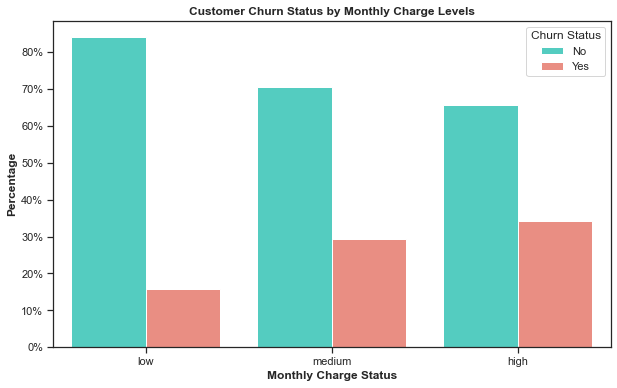

```python
hds.plt.figure(figsize=(10, 6))
barplot = hds.sns.barplot(data=question2_part2, x='monthly_charge_status',\
                      y='percentage_per_monthly_charge_status', hue='churn_status',\
                      palette={'No': 'turquoise', 'Yes': 'salmon'})
PercentFormatter = hds.matplotlib.ticker.PercentFormatter
hds.plt.gca().yaxis.set_major_formatter(PercentFormatter(1))
hds.plt.title('Customer Churn Status by Monthly Charge Levels', fontweight="bold")
hds.plt.xlabel('Monthly Charge Status', fontweight="bold")
hds.plt.ylabel('Percentage', fontweight="bold")
hds.plt.legend(title='Churn Status')
hds.plt.show()
```

**2.2 Quick Summary:**

Here, we see better churn numbers for customers who have 'low' monthly charges.

It would seem that our ability to retain customers seems somehow tied to their price sensitivity. Unless the high-monthly-charge-paying customer is a totally different demographic with a different behavior, we might consider what types of promotions or cost reductions we can give them.

Even if a customer pays less up front (due to this promotion I hereby propose), if we retain them longer they can actually generate a higher lifetime value (LTV) for us, especially when we consider the costs of acquisition that we don't need to spend (or decreased cost, at least).

Table of Contents

*Question 2.3:* *Determine if there is a relationship between the tenure of a customer and their likelihood to churn. Use appropriate statistical tests or visualizations to support your conclusion.*

```python
ias_df_wrangled.head()
```

|  | customerID | gender | SeniorCitizen | Partner | Dependents | tenure | PhoneService | MultipleLines | InternetService | OnlineSecurity | OnlineBackup | DeviceProtection | TechSupport | StreamingTV | StreamingMovies | Contract | PaperlessBilling | PaymentMethod | MonthlyCharges | TotalCharges | Churn | monthlycharge_status |
| --- | --- | --- | --- | --- | --- | --- | --- | --- | --- | --- | --- | --- | --- | --- | --- | --- | --- | --- | --- | --- | --- | --- |
| 0 | 7590-VHVEG | Female | 0 | Yes | No | 1 | No | No phone service | DSL | No | Yes | No | No | No | No | Month-to-month | Yes | Electronic check | 29.85 | 29.85 | No | low |
| 1 | 5575-GNVDE | Male | 0 | No | No | 34 | Yes | No | DSL | Yes | No | Yes | No | No | No | One year | No | Mailed check | 56.95 | 1889.50 | No | medium |
| 2 | 3668-QPYBK | Male | 0 | No | No | 2 | Yes | No | DSL | Yes | Yes | No | No | No | No | Month-to-month | Yes | Mailed check | 53.85 | 108.15 | Yes | medium |
| 3 | 7795-CFOCW | Male | 0 | No | No | 45 | No | No phone service | DSL | Yes | No | Yes | Yes | No | No | One year | No | Bank transfer (automatic) | 42.30 | 1840.75 | No | low |
| 4 | 9237-HQITU | Female | 0 | No | No | 2 | Yes | No | Fiber optic | No | No | No | No | No | No | Month-to-month | Yes | Electronic check | 70.70 | 151.65 | Yes | medium |

```python
ias_q_2_3 = HaywardSQLAnalysis("ias")
ias_q_2_3.sendToSQL(ias_df_wrangled, "ias")
```

```python
question2_part3 = ias_q_2_3.inlineSQL(f"""
SELECT
    tenure as tenure,
    churn as churn_status,
    count(distinct customerID) as customers,
    (
      1.0*count(distinct customerID))
        /
    sum(count(distinct customerID)) over(partition by monthlycharge_status
    ) as percentage_per_monthly_charge_status
FROM ias
GROUP BY 1, 2
ORDER BY 1 ASC
""")
```

```python
question2_part3
```

|  | tenure | churn_status | customers | percentage_per_monthly_charge_status |
| --- | --- | --- | --- | --- |
| 0 | 1 | No | 233 | 0.12 |
| 1 | 1 | Yes | 379 | 0.19 |
| 2 | 2 | No | 115 | 0.05 |
| 3 | 2 | Yes | 123 | 0.05 |
| 4 | 3 | No | 105 | 0.04 |
| ... | ... | ... | ... | ... |
| 140 | 71 | No | 164 | 0.06 |
| 141 | 71 | Yes | 6 | 0.00 |
| 142 | 72 | No | 355 | 0.14 |
| 143 | 72 | Yes | 6 | 0.00 |
| 144 | 2000 | Yes | 1 | 0.00 |

145 rows × 4 columns

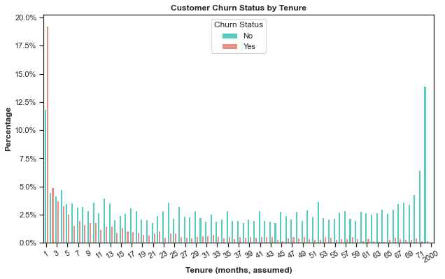

```python
hds.plt.figure(figsize=(10, 6))
barplot = hds.sns.barplot(data=question2_part3, x='tenure',\
                      y='percentage_per_monthly_charge_status', hue='churn_status',\
                      palette={'No': 'turquoise', 'Yes': 'salmon'})
PercentFormatter = hds.matplotlib.ticker.PercentFormatter
hds.plt.gca().yaxis.set_major_formatter(PercentFormatter(1))
hds.plt.title('Customer Churn Status by Tenure', fontweight="bold")
hds.plt.xlabel('Tenure (months, assumed)', fontweight="bold")
hds.plt.ylabel('Percentage', fontweight="bold")
hds.plt.legend(title='Churn Status')
hds.plt.xticks(rotation=30)
#get lables
locs, labels = hds.plt.xticks()
#show every other one
hds.plt.xticks(ticks=locs[::2], labels=[label.get_text() for label in labels[::2]])
hds.plt.show()
```

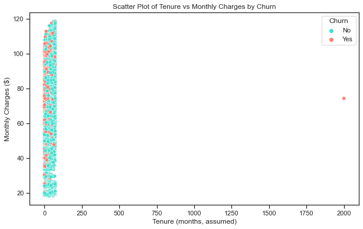

```python
hds.plt.figure(figsize=(10, 6))
hds.sns.scatterplot(data=ias_df_wrangled, x='tenure', y='MonthlyCharges', hue='Churn',\
                palette={'Yes': 'salmon', 'No': 'turquoise'})
hds.plt.title('Scatter Plot of Tenure vs Monthly Charges by Churn')
hds.plt.xlabel('Tenure (months, assumed)')
hds.plt.ylabel('Monthly Charges ($)')
hds.plt.legend(title='Churn')
hds.plt.show()
```

```python
#remove outlier of someone with a 2000 (likely month) tenure
ias_df_wrangled = ias_df_wrangled[ias_df_wrangled['tenure'] < 250]
```

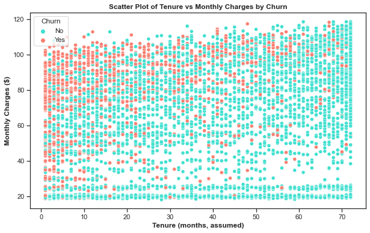

```python
hds.plt.figure(figsize=(10, 6))
hds.sns.scatterplot(data=ias_df_wrangled, x='tenure', y='MonthlyCharges', hue='Churn',\
                palette={'Yes': 'salmon', 'No': 'turquoise'})
hds.plt.title('Scatter Plot of Tenure vs Monthly Charges by Churn', fontweight="bold")
hds.plt.xlabel('Tenure (months, assumed)', fontweight="bold")
hds.plt.ylabel('Monthly Charges ($)', fontweight="bold")
hds.plt.legend(title='Churn')
hds.plt.show()
```

```python
#you can see that can't think about churn, without thinking about charge
#we also have a bit of a tautology where, by definition, no churn means longer tenure, so we'll have to think about
#that as well
```

```python
#grab the columns
ias_df_wrangled.columns
```

```
Index(['customerID', 'gender', 'SeniorCitizen', 'Partner', 'Dependents',
       'tenure', 'PhoneService', 'MultipleLines', 'InternetService',
       'OnlineSecurity', 'OnlineBackup', 'DeviceProtection', 'TechSupport',
       'StreamingTV', 'StreamingMovies', 'Contract', 'PaperlessBilling',
       'PaymentMethod', 'MonthlyCharges', 'TotalCharges', 'Churn',
       'monthlycharge_status'],
      dtype='object')
```

```python
#adjust for categoricals
ias_df_wrangled_dummies = hds.pd.get_dummies(ias_df_wrangled[['gender','Partner','Dependents',\
                        'SeniorCitizen','PhoneService','MultipleLines',\
            'InternetService','OnlineSecurity', 'OnlineBackup', 'DeviceProtection', 'TechSupport',
       'StreamingTV', 'StreamingMovies', 'Contract', 'PaperlessBilling',
       'PaymentMethod','monthlycharge_status']]\
                                             ,drop_first=True)
#drop first is to avoid dummy variable trap
```

```python
ias_df_wrangled_dummies.head()
```

|  | gender_Male | Partner_Yes | Dependents_Yes | SeniorCitizen_1 | PhoneService_Yes | MultipleLines_No phone service | MultipleLines_Yes | InternetService_Fiber optic | InternetService_No | OnlineSecurity_No internet service | OnlineSecurity_Yes | OnlineBackup_No internet service | OnlineBackup_Yes | DeviceProtection_No internet service | DeviceProtection_Yes | TechSupport_No internet service | TechSupport_Yes | StreamingTV_No internet service | StreamingTV_Yes | StreamingMovies_No internet service | StreamingMovies_Yes | Contract_One year | Contract_Two year | PaperlessBilling_Yes | PaymentMethod_Credit card (automatic) | PaymentMethod_Electronic check | PaymentMethod_Mailed check | monthlycharge_status_medium | monthlycharge_status_high |
| --- | --- | --- | --- | --- | --- | --- | --- | --- | --- | --- | --- | --- | --- | --- | --- | --- | --- | --- | --- | --- | --- | --- | --- | --- | --- | --- | --- | --- | --- |
| 0 | 0 | 1 | 0 | 0 | 0 | 1 | 0 | 0 | 0 | 0 | 0 | 0 | 1 | 0 | 0 | 0 | 0 | 0 | 0 | 0 | 0 | 0 | 0 | 1 | 0 | 1 | 0 | 0 | 0 |
| 1 | 1 | 0 | 0 | 0 | 1 | 0 | 0 | 0 | 0 | 0 | 1 | 0 | 0 | 0 | 1 | 0 | 0 | 0 | 0 | 0 | 0 | 1 | 0 | 0 | 0 | 0 | 1 | 1 | 0 |
| 2 | 1 | 0 | 0 | 0 | 1 | 0 | 0 | 0 | 0 | 0 | 1 | 0 | 1 | 0 | 0 | 0 | 0 | 0 | 0 | 0 | 0 | 0 | 0 | 1 | 0 | 0 | 1 | 1 | 0 |
| 3 | 1 | 0 | 0 | 0 | 0 | 1 | 0 | 0 | 0 | 0 | 1 | 0 | 0 | 0 | 1 | 0 | 1 | 0 | 0 | 0 | 0 | 1 | 0 | 0 | 0 | 0 | 0 | 0 | 0 |
| 4 | 0 | 0 | 0 | 0 | 1 | 0 | 0 | 1 | 0 | 0 | 0 | 0 | 0 | 0 | 0 | 0 | 0 | 0 | 0 | 0 | 0 | 0 | 0 | 1 | 0 | 1 | 0 | 1 | 0 |

```python
#merge back in the encoded categoricals, and drop the original categoricals
ias_df_wrangled_ml = hds.pd.concat([ias_df_wrangled, ias_df_wrangled_dummies],axis=1)
#drop the categoricals that we just converted into dummies; we can grab that list we just used
ias_df_wrangled_ml = ias_df_wrangled_ml.drop(['gender','Partner','Dependents',\
                        'SeniorCitizen','PhoneService','MultipleLines',\
            'InternetService','OnlineSecurity', 'OnlineBackup', 'DeviceProtection', 'TechSupport',
       'StreamingTV', 'StreamingMovies', 'Contract', 'PaperlessBilling',
       'PaymentMethod','monthlycharge_status'], axis=1)
```

```python
ias_df_wrangled_ml.head()
```

|  | customerID | tenure | MonthlyCharges | TotalCharges | Churn | gender_Male | Partner_Yes | Dependents_Yes | SeniorCitizen_1 | PhoneService_Yes | MultipleLines_No phone service | MultipleLines_Yes | InternetService_Fiber optic | InternetService_No | OnlineSecurity_No internet service | OnlineSecurity_Yes | OnlineBackup_No internet service | OnlineBackup_Yes | DeviceProtection_No internet service | DeviceProtection_Yes | TechSupport_No internet service | TechSupport_Yes | StreamingTV_No internet service | StreamingTV_Yes | StreamingMovies_No internet service | StreamingMovies_Yes | Contract_One year | Contract_Two year | PaperlessBilling_Yes | … |
| --- | --- | --- | --- | --- | --- | --- | --- | --- | --- | --- | --- | --- | --- | --- | --- | --- | --- | --- | --- | --- | --- | --- | --- | --- | --- | --- | --- | --- | --- | --- |
| 0 | 7590-VHVEG | 1 | 29.85 | 29.85 | No | 0 | 1 | 0 | 0 | 0 | 1 | 0 | 0 | 0 | 0 | 0 | 0 | 1 | 0 | 0 | 0 | 0 | 0 | 0 | 0 | 0 | 0 | 0 | 1 | … |
| 1 | 5575-GNVDE | 34 | 56.95 | 1889.50 | No | 1 | 0 | 0 | 0 | 1 | 0 | 0 | 0 | 0 | 0 | 1 | 0 | 0 | 0 | 1 | 0 | 0 | 0 | 0 | 0 | 0 | 1 | 0 | 0 | … |
| 2 | 3668-QPYBK | 2 | 53.85 | 108.15 | Yes | 1 | 0 | 0 | 0 | 1 | 0 | 0 | 0 | 0 | 0 | 1 | 0 | 1 | 0 | 0 | 0 | 0 | 0 | 0 | 0 | 0 | 0 | 0 | 1 | … |
| 3 | 7795-CFOCW | 45 | 42.30 | 1840.75 | No | 1 | 0 | 0 | 0 | 0 | 1 | 0 | 0 | 0 | 0 | 1 | 0 | 0 | 0 | 1 | 0 | 1 | 0 | 0 | 0 | 0 | 1 | 0 | 0 | … |
| 4 | 9237-HQITU | 2 | 70.70 | 151.65 | Yes | 0 | 0 | 0 | 0 | 1 | 0 | 0 | 1 | 0 | 0 | 0 | 0 | 0 | 0 | 0 | 0 | 0 | 0 | 0 | 0 | 0 | 0 | 0 | 1 | … |

```python
#need to code Churn into a 1 or a 0
ias_df_wrangled_ml['churn_code'] = ias_df_wrangled_ml['Churn'].map({'Yes': 1, 'No': 0})
```

```python
ias_tenure_and_churn_thinktank = HaywardDataScience(ias_df_wrangled_ml)
```

```python
#grab the columns
ias_df_wrangled_ml.columns
```

```
Index(['customerID', 'tenure', 'MonthlyCharges', 'TotalCharges', 'Churn',
       'gender_Male', 'Partner_Yes', 'Dependents_Yes', 'SeniorCitizen_1',
       'PhoneService_Yes', 'MultipleLines_No phone service',
       'MultipleLines_Yes', 'InternetService_Fiber optic',
       'InternetService_No', 'OnlineSecurity_No internet service',
       'OnlineSecurity_Yes', 'OnlineBackup_No internet service',
       'OnlineBackup_Yes', 'DeviceProtection_No internet service',
       'DeviceProtection_Yes', 'TechSupport_No internet service',
       'TechSupport_Yes', 'StreamingTV_No internet service', 'StreamingTV_Yes',
       'StreamingMovies_No internet service', 'StreamingMovies_Yes',
       'Contract_One year', 'Contract_Two year', 'PaperlessBilling_Yes',
       'PaymentMethod_Credit card (automatic)',
       'PaymentMethod_Electronic check', 'PaymentMethod_Mailed check',
       'monthlycharge_status_medium', 'monthlycharge_status_high',
       'churn_code'],
      dtype='object')
```

```python
ias_tenure_and_churn_thinktank.set_features(['tenure', 'MonthlyCharges', 'TotalCharges',
       'gender_Male', 'Partner_Yes', 'Dependents_Yes',
       'SeniorCitizen_1', 'PhoneService_Yes', 'MultipleLines_No phone service',
       'MultipleLines_Yes', 'InternetService_Fiber optic',
       'InternetService_No', 'OnlineSecurity_No internet service',
       'OnlineSecurity_Yes', 'OnlineBackup_No internet service',
       'OnlineBackup_Yes', 'DeviceProtection_No internet service',
       'DeviceProtection_Yes', 'TechSupport_No internet service',
       'TechSupport_Yes', 'StreamingTV_No internet service', 'StreamingTV_Yes',
       'StreamingMovies_No internet service', 'StreamingMovies_Yes',
       'Contract_One year', 'Contract_Two year', 'PaperlessBilling_Yes',
       'PaymentMethod_Credit card (automatic)',
       'PaymentMethod_Electronic check', 'PaymentMethod_Mailed check',
       'monthlycharge_status_medium','monthlycharge_status_high'])
# notice I'm excluding some, such as 'customerID' and 'Churn' or 'churn_code'
```

```python
ias_tenure_and_churn_thinktank.set_target('churn_code')
```

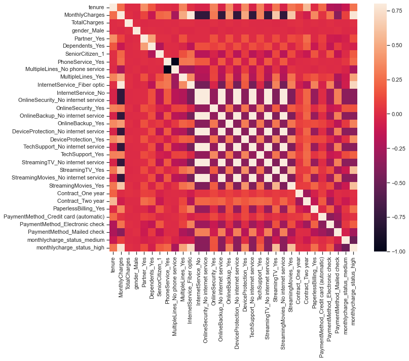

```python
# we see a lot of colinearity here; but fine for just seeing what relationships are out there
ias_tenure_and_churn_thinktank.heatmap()
```

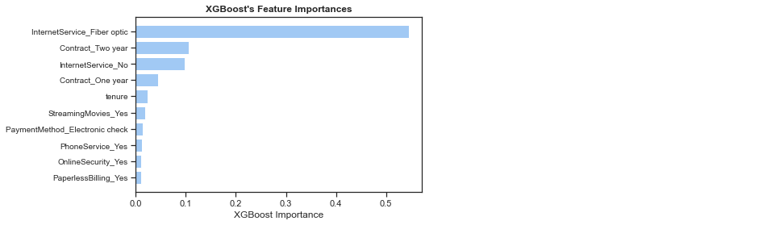

```
F1: 0.5779036827195467
ROC_AUC: 0.705257551071563
Accuracy: 0.7879003558718861
Precision: 0.6559485530546624
Recall: 0.5164556962025316
```

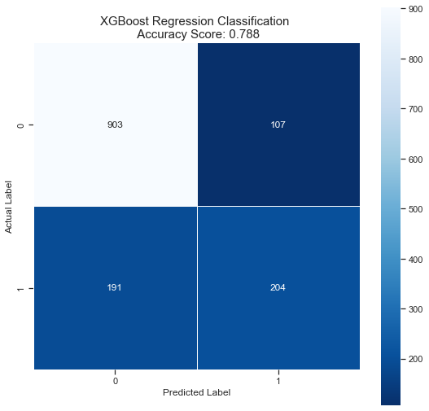

```python
ias_tenure_and_churn_thinktank.xgboost_classification_modeler()
```

```python
ias_tenure_and_churn_thinktank.run_logistic_regression_sklearn(test_size = 0.2, \
                                                               display_how_many_features=10,\
                                                               after_term_of_log_odds_title='Churning')
```

```
_________Logistic Regression Classification_________

Scored Against Itself
Accuracy Score: 0.807

Scored Against Test Data
Accuracy Score: 0.799
_________Cross-Validation Scoring for Logistic Regression Classification_________
Accuracy: 0.803
Precision: 0.65
Recall: 0.552
```

|  | Feature | Logistic Regression Coefficient | Percent Change in Odds of Churning |
| --- | --- | --- | --- |
| 0 | tenure | -0.86 | -57.64 |
| 1 | Contract_Two year | -0.62 | -45.98 |
| 2 | InternetService_Fiber optic | 0.51 | 67.17 |
| 3 | Contract_One year | -0.29 | -25.23 |
| 4 | monthlycharge_status_high | -0.17 | -15.30 |
| 5 | StreamingMovies_Yes | 0.16 | 17.27 |
| 6 | PaymentMethod_Electronic check | 0.15 | 16.61 |
| 7 | MultipleLines_Yes | 0.15 | 16.61 |
| 8 | TechSupport_Yes | -0.15 | -13.65 |
| 9 | PaperlessBilling_Yes | 0.14 | 15.55 |

**2.3 Quick Summary:**

Briefly, **yes**, we see a relationship between tenure and churn.

We should also note that, definitionally, someone who has not churned, will have a longer tenure (which I'm assuming means months in the product/program).

We can also see quite a lot of the features are positively correlated with one another, and we'd whittle them down in practice.

We see a relationship in the scatter plot above where once you get to **50** months tenure, we see very little churn, and in the first **15** or so months we see a lot of churn.

More quantitatively, in our `scikit-learn`logistic regression above, we see that the coefficient is negative because an increase in tenure leads to a decrease in the odds of churning (i.e., it's less likely they will churn as they stay longer with the service). Thus, for every month longer a customer in tenure, that customer is **57.64%** less likely to churn.

And if we look at the churn comparison by tenure graph, looks like churn starts to level off once we reach **20** months.

Table of Contents

*Question 2.4:* *How do the kurtosis and skewness in a price distribution indicate the revenue contributions from different customer segments?*

```python
low_cust = ias_df_wrangled[ias_df_wrangled['monthlycharge_status'] == 'low']
medium_cust = ias_df_wrangled[ias_df_wrangled['monthlycharge_status'] == 'medium']
high_cust = ias_df_wrangled[ias_df_wrangled['monthlycharge_status'] == 'high']
```

*Low Customers*

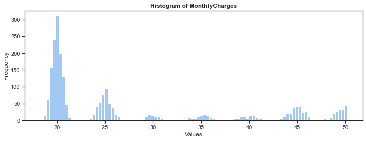

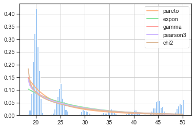

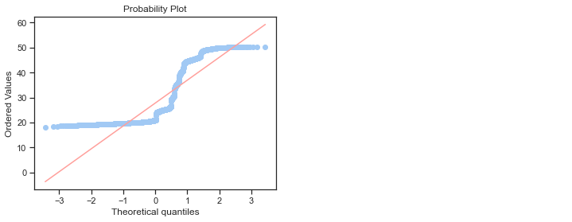

```python
HaywardGeneral.distribution_visualizer_and_fitter(low_cust,'MonthlyCharges')
```

```python
hds.skew(low_cust['MonthlyCharges'])
```

```
1.0246467552012444
```

```python
hds.kurtosis(low_cust['MonthlyCharges'])
```

```
-0.5643106250547567
```

*Medium Customers*

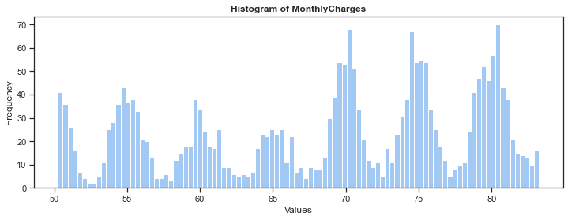

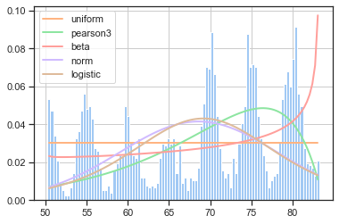

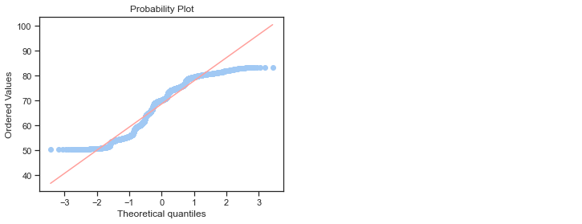

```python
HaywardGeneral.distribution_visualizer_and_fitter(medium_cust,'MonthlyCharges')
```

```python
hds.skew(medium_cust['MonthlyCharges'])
```

```
-0.3636261625723172
```

```python
hds.kurtosis(medium_cust['MonthlyCharges'])
```

```
-1.1359978622467777
```

*High Customers*

Table of Contents

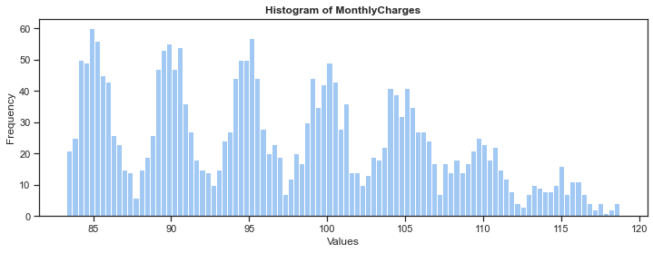

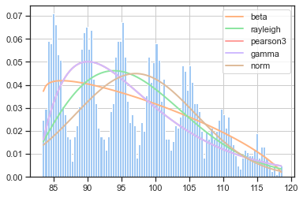

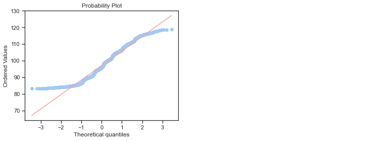

```python
HaywardGeneral.distribution_visualizer_and_fitter(high_cust,'MonthlyCharges')
```

```python
hds.skew(high_cust['MonthlyCharges'])
```

```
0.29878956117546773
```

```python
hds.kurtosis(high_cust['MonthlyCharges'])
```

```
-0.8917306408394614
```

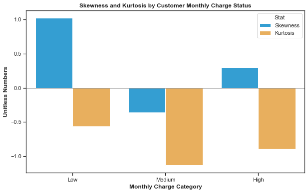

```python
skew_kurt_df = hds.pd.DataFrame({
    'Category': ['Low', 'Medium', 'High'],
    'Skewness': [
        hds.skew(low_cust['MonthlyCharges']),
        hds.skew(medium_cust['MonthlyCharges']),
        hds.skew(high_cust['MonthlyCharges'])
    ],
    'Kurtosis': [
        hds.kurtosis(low_cust['MonthlyCharges']),
        hds.kurtosis(medium_cust['MonthlyCharges']),
        hds.kurtosis(high_cust['MonthlyCharges'])
    ]
})

# melting will help us with the hews
skew_kurt_melted = skew_kurt_df.melt(id_vars='Category', var_name='Stat', value_name='Value')

hds.plt.figure(figsize=(10, 6))
hds.sns.barplot(data=skew_kurt_melted, x='Category', y='Value', hue='Stat', palette=['#1aa7ec', '#ffb347'])
hds.plt.axhline(0, color='gray', linewidth=0.8)  # Adding a line at y=0 for reference
hds.plt.title('Skewness and Kurtosis by Customer Monthly Charge Status', fontweight='bold')
hds.plt.ylabel('Unitless Numbers', fontweight='bold')
hds.plt.xlabel('Monthly Charge Category', fontweight='bold')
hds.plt.show()
```

**2.4 Quick Summary:**

Across all categories, we see low and negative **kurtosis**, which means the herd is bunched together, generally, and we don't see too many outliers.